# Analisis Incial - Tarea 1

Nombre: Paulina Aldape Bretado

### Importing Libraries

```python
import numpy as np # linear algebra
import pandas as pd # data processing
import matplotlib.pyplot as plt
import seaborn as sns
# Input data files are available in the "../input/" directory.
import os
```

### Loading the Dataset

```python
empleo=pd.read_csv('/content/BD Tarea 1 Analisis inicial.csv')
```

#### First 10 values

```python
empleo.head(10)
```

|  | t_loc_tri | h_mud | sex | eda | cs_p13_1 | n_hij | e_con | zona | clase1 | clase2 | domestico | anios_esc | t_tra | hrsocup | ingocup |
| --- | --- | --- | --- | --- | --- | --- | --- | --- | --- | --- | --- | --- | --- | --- | --- |
| 0 | 1 | 0 | 1 | 43 | 7 |  | 6 | 2 | 1 | 1 | 3 | 16 | 1 | 40 | 20000 |
| 1 | 1 | 0 | 2 | 67 | 4 | 2 | 2 | 2 | 1 | 1 | 3 | 12 | 1 | 7 | 0 |
| 2 | 1 | 0 | 2 | 26 | 7 | 0 | 6 | 2 | 1 | 1 | 3 | 17 | 1 | 40 | 0 |
| 3 | 1 | 0 | 2 | 28 | 7 | 0 | 6 | 2 | 1 | 1 | 3 | 16 | 1 | 30 | 0 |
| 4 | 1 | 0 | 2 | 30 | 7 | 0 | 6 | 2 | 1 | 1 | 3 | 16 | 1 | 40 | 0 |
| 5 | 1 | 0 | 2 | 26 | 7 | 0 | 6 | 2 | 1 | 1 | 3 | 17 | 1 | 50 | 0 |
| 6 | 1 | 0 | 1 | 59 | 2 |  | 6 | 2 | 1 | 1 | 3 | 6 | 1 | 60 | 0 |
| 7 | 1 | 0 | 2 | 47 | 6 | 1 | 2 | 2 | 1 | 1 | 3 | 12 | 2 | 36 | 5160 |
| 8 | 1 | 0 | 1 | 64 | 4 |  | 3 | 2 | 1 | 1 | 3 | 12 | 2 | 72 | 0 |
| 9 | 1 | 0 | 1 | 37 | 3 |  | 5 | 2 | 1 | 1 | 4 | 9 | 1 | 48 | 14000 |

#### Shape of the dataset

```python
empleo.shape
```

```
(185627, 15)
```

#### Print the name of columns

```python
empleo.columns
```

```
Index(['t_loc_tri', 'h_mud', 'sex', 'eda', 'cs_p13_1', 'n_hij', 'e_con',
       'zona', 'clase1', 'clase2', 'domestico', 'anios_esc', 't_tra',
       'hrsocup', 'ingocup'],
      dtype='object')
```

#### Check for NULL Values

```python
empleo.isnull().sum()
```

```
t_loc_tri    0
h_mud        0
sex          0
eda          0
cs_p13_1     0
n_hij        0
e_con        0
zona         0
clase1       0
clase2       0
domestico    0
anios_esc    0
t_tra        0
hrsocup      0
ingocup      0
dtype: int64
```

#### Check unique values

```python
empleo.nunique()
```

```
t_loc_tri       4
h_mud           4
sex             2
eda            86
cs_p13_1       11
n_hij          24
e_con           7
zona            2
clase1          1
clase2          2
domestico       5
anios_esc      25
t_tra           2
hrsocup       117
ingocup      2037
dtype: int64
```

#### Check for Duplicate values

```python
empleo.duplicated().sum()
```

```
11278
```

Existen 11,278 valores duplicados que se requieren remover de la base de datos.

#### Make a copy of the dataset

```python
df = empleo.copy()
```

```python
df.shape
```

```
(185627, 15)
```

#### Drop NULL values

```python
df=df.dropna()
df.shape
```

```
(185627, 15)
```

#### Print first 10 values

```python
df.head(10)
```

|  | t_loc_tri | h_mud | sex | eda | cs_p13_1 | n_hij | e_con | zona | clase1 | clase2 | domestico | anios_esc | t_tra | hrsocup | ingocup |
| --- | --- | --- | --- | --- | --- | --- | --- | --- | --- | --- | --- | --- | --- | --- | --- |
| 0 | 1 | 0 | 1 | 43 | 7 |  | 6 | 2 | 1 | 1 | 3 | 16 | 1 | 40 | 20000 |
| 1 | 1 | 0 | 2 | 67 | 4 | 2 | 2 | 2 | 1 | 1 | 3 | 12 | 1 | 7 | 0 |
| 2 | 1 | 0 | 2 | 26 | 7 | 0 | 6 | 2 | 1 | 1 | 3 | 17 | 1 | 40 | 0 |
| 3 | 1 | 0 | 2 | 28 | 7 | 0 | 6 | 2 | 1 | 1 | 3 | 16 | 1 | 30 | 0 |
| 4 | 1 | 0 | 2 | 30 | 7 | 0 | 6 | 2 | 1 | 1 | 3 | 16 | 1 | 40 | 0 |
| 5 | 1 | 0 | 2 | 26 | 7 | 0 | 6 | 2 | 1 | 1 | 3 | 17 | 1 | 50 | 0 |
| 6 | 1 | 0 | 1 | 59 | 2 |  | 6 | 2 | 1 | 1 | 3 | 6 | 1 | 60 | 0 |
| 7 | 1 | 0 | 2 | 47 | 6 | 1 | 2 | 2 | 1 | 1 | 3 | 12 | 2 | 36 | 5160 |
| 8 | 1 | 0 | 1 | 64 | 4 |  | 3 | 2 | 1 | 1 | 3 | 12 | 2 | 72 | 0 |
| 9 | 1 | 0 | 1 | 37 | 3 |  | 5 | 2 | 1 | 1 | 4 | 9 | 1 | 48 | 14000 |

#### Revisar los tipos de datos de las variables

```python
df.dtypes
```

```
t_loc_tri     int64
h_mud         int64
sex           int64
eda           int64
cs_p13_1      int64
n_hij        object
e_con         int64
zona          int64
clase1        int64
clase2        int64
domestico     int64
anios_esc     int64
t_tra         int64
hrsocup       int64
ingocup       int64
dtype: object
```

La mayoria de las variables no estan bien catalogadas, esto debido a que la mayoria son variables categoricas con excepcion de la variable de edad, numero de hijos, años de escolaridad, horas trabajadas y ingreso. Por lo que se deben de categorizar de la forma correcta para realizar la limpieza de la base de datos.

```python
# Convertir los campos correspondientes en string
df['t_loc_tri'] = pd.Series(df['t_loc_tri'], dtype="string")
df['sex'] = pd.Series(df['sex'], dtype="string")
df['cs_p13_1'] = pd.Series(df['cs_p13_1'], dtype="string")
df['e_con'] = pd.Series(df['e_con'], dtype="string")
df['zona'] = pd.Series(df['zona'], dtype="string")
df['clase1'] = pd.Series(df['clase1'], dtype="string")
df['clase2'] = pd.Series(df['clase2'], dtype="string")
df['clase1'] = pd.Series(df['clase1'], dtype="string")
df['domestico'] = pd.Series(df['domestico'], dtype="string")
df['t_tra'] = pd.Series(df['t_tra'], dtype="string")
```

```python
df['h_mud'] = pd.Series(df['h_mud'], dtype="int64")
```

```python
df['n_hij'] = pd.Series(df['n_hij'], dtype="int64")
```

```python
df.dtypes
```

```
t_loc_tri    string
h_mud         int64
sex          string
eda           int64
cs_p13_1     string
n_hij        object
e_con        string
zona         string
clase1       string
clase2       string
domestico    string
anios_esc     int64
t_tra        string
hrsocup       int64
ingocup       int64
dtype: object
```

# Data Visualization

### Revisar la variable de clase 2 que será la variable de interes dentro del analisis

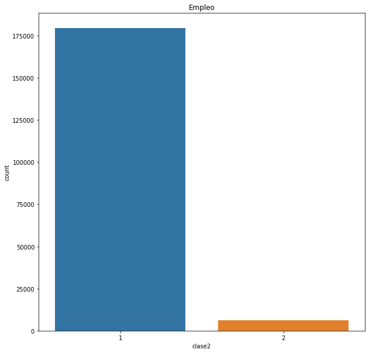

```python
sns.countplot(df['clase2'])
fig = plt.gcf()
fig.set_size_inches(10,10)
plt.title('Empleo')
```

A primera instancia se puede observar que existe un desbalanceo de las clases, que se tendrá que corregir.

### Tamaño de localidad

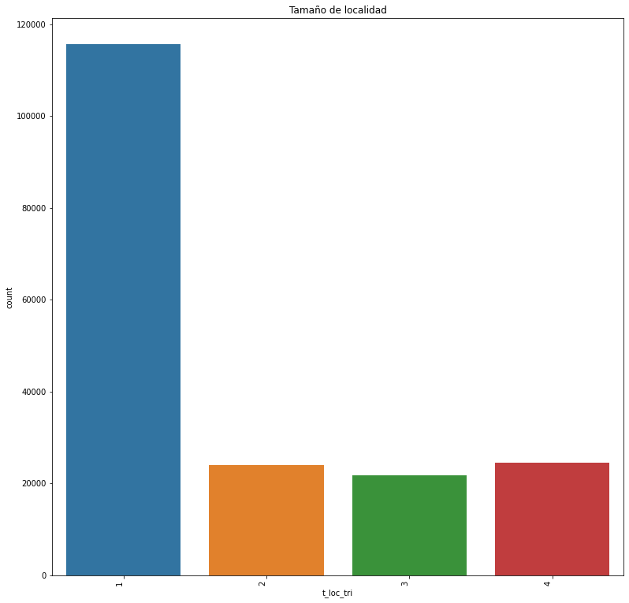

```python
sns.countplot(df['t_loc_tri'])
sns.countplot(df['t_loc_tri']).set_xticklabels(sns.countplot(df['t_loc_tri']).get_xticklabels(), rotation=90, ha="right")
fig = plt.gcf()
fig.set_size_inches(13,13)
plt.title('Tamaño de localidad')
```

### Numero de veces que se han mudado del hogar

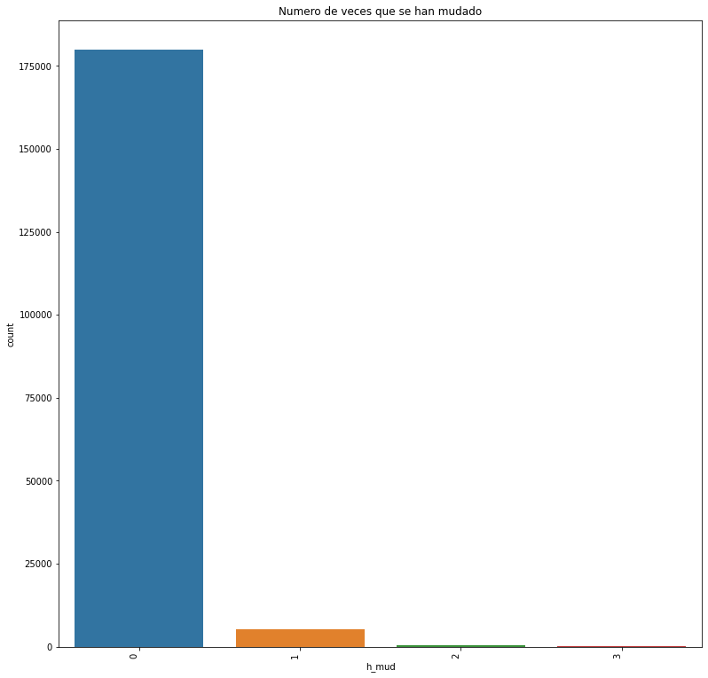

```python
sns.countplot(df['h_mud'])
sns.countplot(df['h_mud']).set_xticklabels(sns.countplot(df['h_mud']).get_xticklabels(), rotation=90, ha="right")
fig = plt.gcf()
fig.set_size_inches(13,13)
plt.title('Numero de veces que se han mudado')
```

### Variable de genero

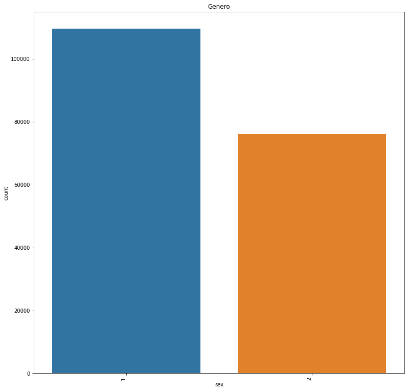

```python
sns.countplot(df['sex'])
sns.countplot(df['sex']).set_xticklabels(sns.countplot(df['sex']).get_xticklabels(), rotation=90, ha="right")
fig = plt.gcf()
fig.set_size_inches(13,13)
plt.title('Genero')
```

### Variable de edad

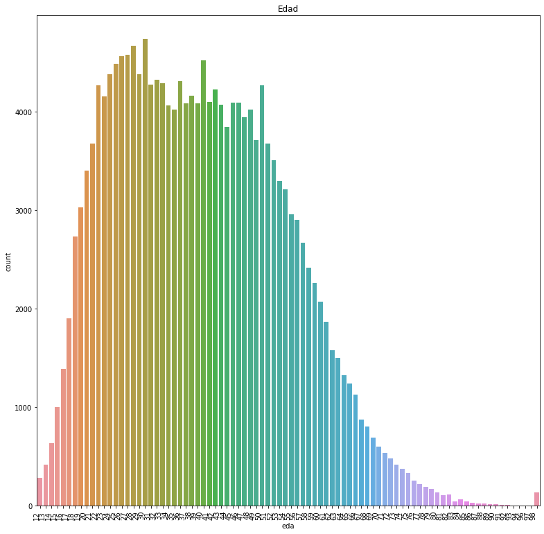

```python
sns.countplot(df['eda'])
sns.countplot(df['eda']).set_xticklabels(sns.countplot(df['eda']).get_xticklabels(), rotation=90, ha="right")
fig = plt.gcf()
fig.set_size_inches(13,13)
plt.title('Edad')
```

Se puede observar que la variable de edad tiene una distribucuon cargada a la izquierda debido a que no hay muchas personas con edades tan avanzadas.

### Variable de nivel de escolaridad

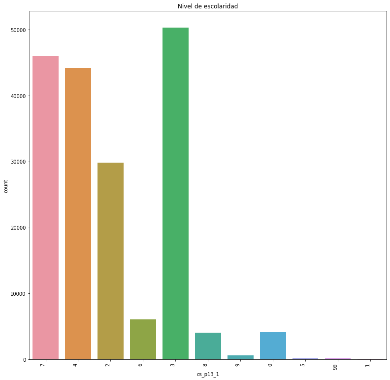

```python
sns.countplot(df['cs_p13_1'])
sns.countplot(df['cs_p13_1']).set_xticklabels(sns.countplot(df['cs_p13_1']).get_xticklabels(), rotation=90, ha="right")
fig = plt.gcf()
fig.set_size_inches(13,13)
plt.title('Nivel de escolaridad')
```

Se observa que la categoria con mas registros es la de secundaria seguida por el nivel de profesional.

### Numero de hijos

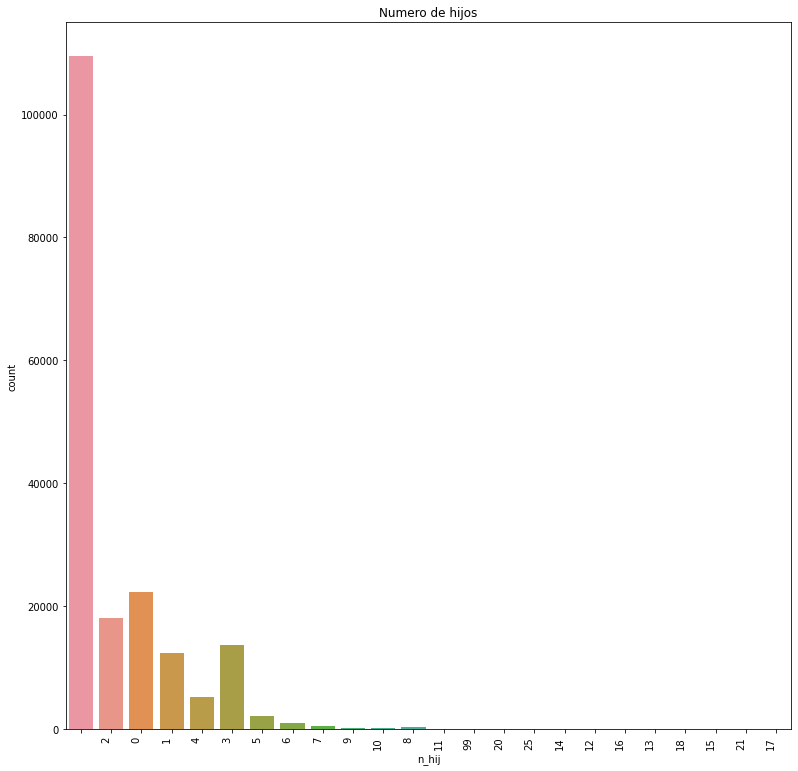

```python
sns.countplot(df['n_hij'])
sns.countplot(df['n_hij']).set_xticklabels(sns.countplot(df['n_hij']).get_xticklabels(), rotation=90, ha="right")
fig = plt.gcf()
fig.set_size_inches(13,13)
plt.title('Numero de hijos')
```

Con el grafico nos podemos dar cuenta que existe un gran numero de regitros que no tienen valor en esta variable que no lo detectaba el comando de isnull debido a que la celda cuenta con espacios en blanco, lo cual lo cuenta como caracter.

### Estado conyugal

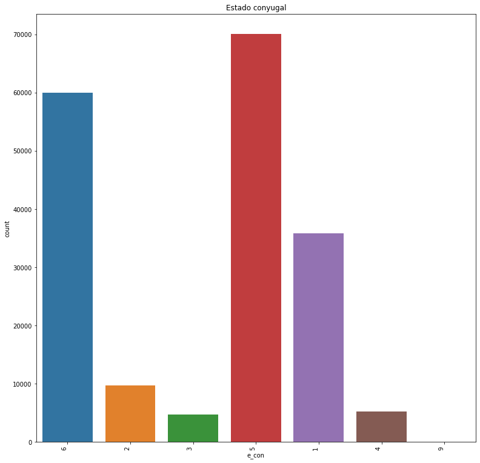

```python
sns.countplot(df['e_con'])
sns.countplot(df['e_con']).set_xticklabels(sns.countplot(df['e_con']).get_xticklabels(), rotation=90, ha="right")
fig = plt.gcf()
fig.set_size_inches(13,13)
plt.title('Estado conyugal')
```

Las dos primeras categorias que resaltan son las de casado y soltero.

### Zona salarial

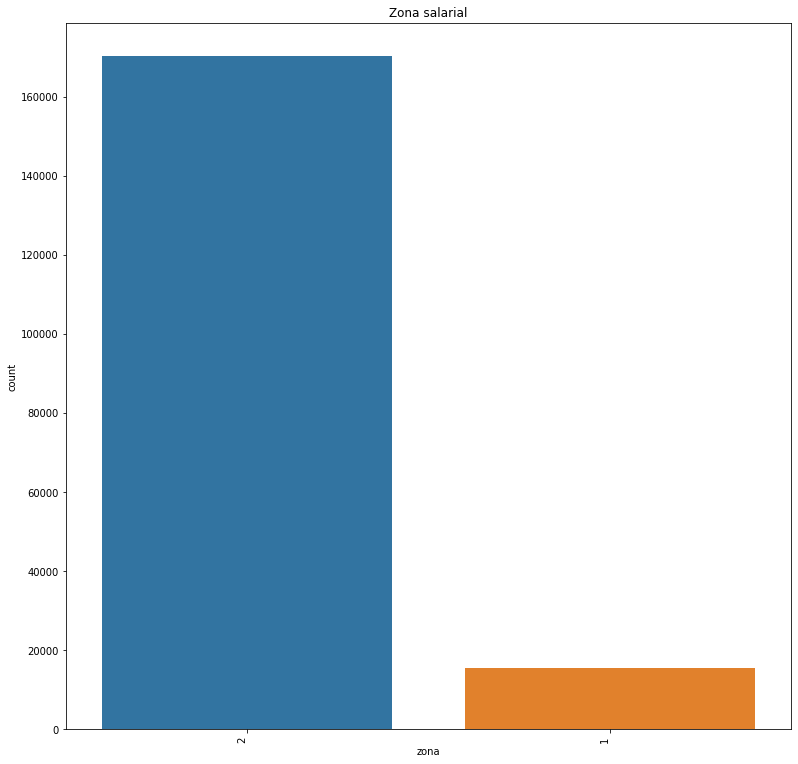

```python
sns.countplot(df['zona'])
sns.countplot(df['zona']).set_xticklabels(sns.countplot(df['zona']).get_xticklabels(), rotation=90, ha="right")
fig = plt.gcf()
fig.set_size_inches(13,13)
plt.title('Zona salarial')
```

La zona salarial que predomina es la de "Resto del pais" debido a que son pocos los estados que se encuentran en la zona fronteriza.

### Variable de clase

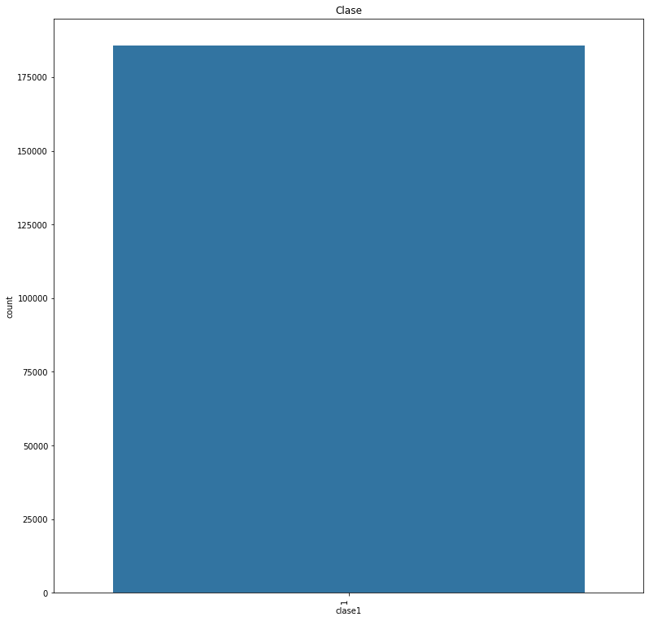

```python
sns.countplot(df['clase1'])
sns.countplot(df['clase1']).set_xticklabels(sns.countplot(df['clase1']).get_xticklabels(), rotation=90, ha="right")
fig = plt.gcf()
fig.set_size_inches(13,13)
plt.title('Clase')
```

Podemos observar que la variable de clase solo tiene un valor, esto debido a que el grupo que se esta analizando solo corresponde a la poblacion economicamente activa.

### Clasificacion por condicion de actividad

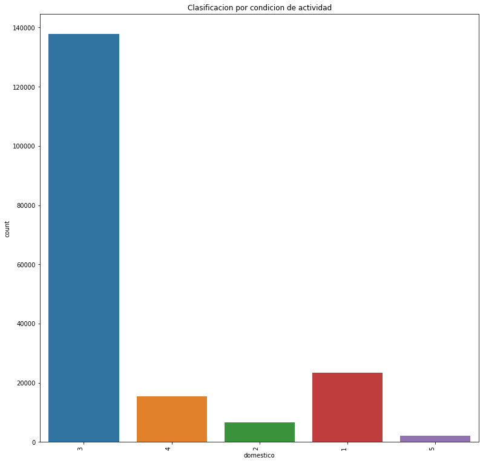

```python
sns.countplot(df['domestico'])
sns.countplot(df['domestico']).set_xticklabels(sns.countplot(df['domestico']).get_xticklabels(), rotation=90, ha="right")
fig = plt.gcf()
fig.set_size_inches(13,13)
plt.title('Clasificacion por condicion de actividad')
```

La actividad que sobresale de las demás es que ademas de su ocupacion se dedican a los quehaceres domesticos.

### Años de escolaridad

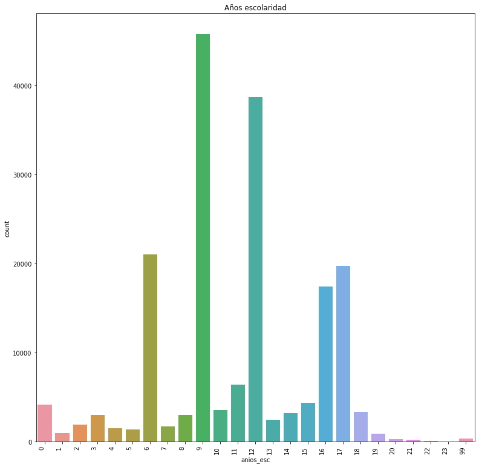

```python
sns.countplot(df['anios_esc'])
sns.countplot(df['anios_esc']).set_xticklabels(sns.countplot(df['anios_esc']).get_xticklabels(), rotation=90, ha="right")
fig = plt.gcf()
fig.set_size_inches(13,13)
plt.title('Años escolaridad')
```

Los años de escolaridad que mas se repiten son 9, que corresponde a un nivel de secundaria.

### Total de trabajos

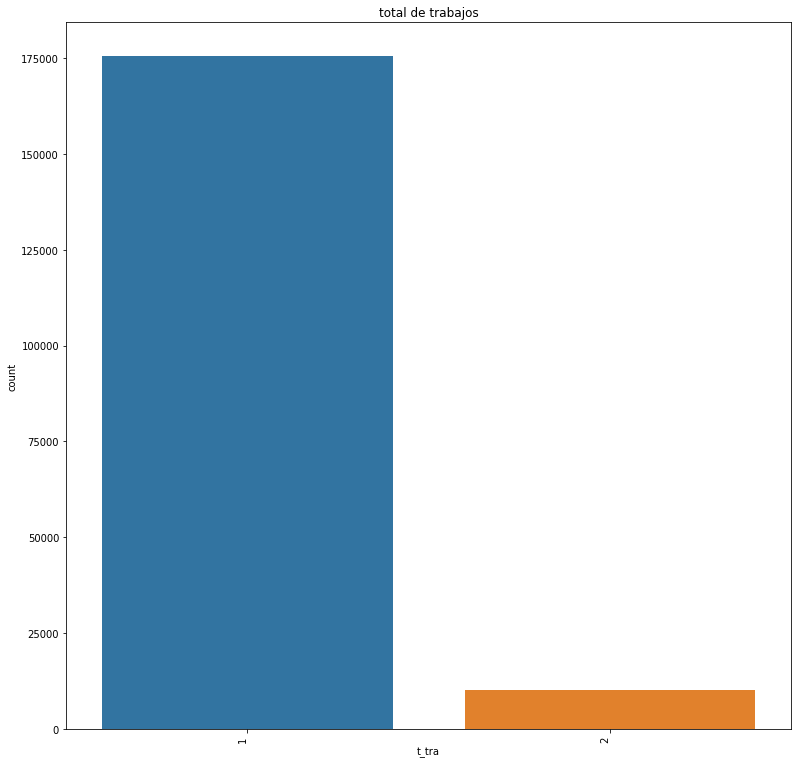

```python
sns.countplot(df['t_tra'])
sns.countplot(df['t_tra']).set_xticklabels(sns.countplot(df['t_tra']).get_xticklabels(), rotation=90, ha="right")
fig = plt.gcf()
fig.set_size_inches(13,13)
plt.title('total de trabajos')
```

La mayoria de las personas entrevistadas solo tiene un trabajo.

### Horas ocupadas

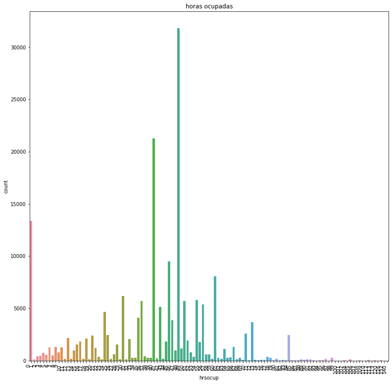

```python
sns.countplot(df['hrsocup'])
sns.countplot(df['hrsocup']).set_xticklabels(sns.countplot(df['hrsocup']).get_xticklabels(), rotation=90, ha="right")
fig = plt.gcf()
fig.set_size_inches(13,13)
plt.title('horas ocupadas')
```

### Ingreso mensual

[output not shown]

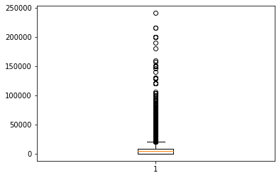

```python
import matplotlib.pyplot as plt
plt.boxplot(df['ingocup'])
```

Se puede observar que hay datos outlayers que se ocuparian remover de la base para poder realizar el analisis

### Pie-chart for the Tipo de Empleo: Ocupado o Desocupado

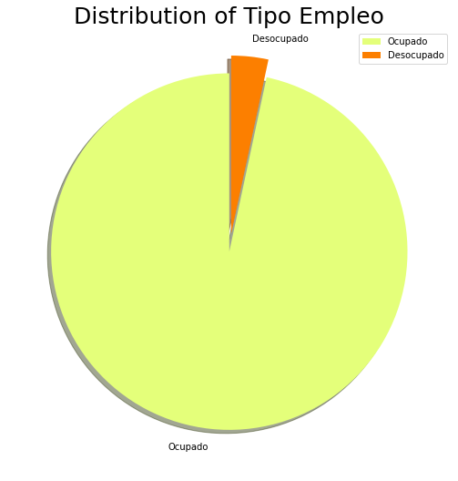

```python
labels = ['Ocupado', 'Desocupado']
size = df['clase2'].value_counts()
colors = plt.cm.Wistia(np.linspace(0, 1, 2))
explode = [0, 0.1]
plt.rcParams['figure.figsize'] = (9, 9)
plt.pie(size,labels=labels, colors = colors, explode = explode, shadow = True, startangle = 90)
plt.title('Distribution of Tipo Empleo', fontsize = 25)
plt.legend()
plt.show()
```

### Pie-chart for genero

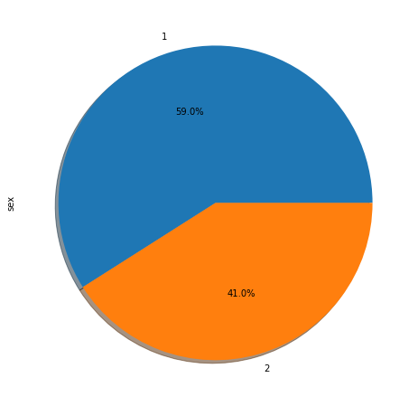

```python
df['sex'].value_counts().plot.pie(autopct='%1.1f%%',shadow=True,figsize=(10,8))
plt.show()
```

### Pay chart de nivel de estado conyugal

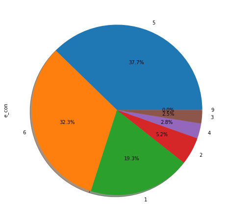

```python
df['e_con'].value_counts().plot.pie(autopct='%1.1f%%',shadow=True,figsize=(10,8))
plt.show()
```

# Primeras impresiones

Realizando este analisis incial de la base de datos, se pudo observar que la mayoria de las variables son categóricas, que existen datos con espacios que se ocuparian remover. Adicionalmente, la variable de interes, que es el tipo de empleo, es decir, si la persona se encuentra empleada o desempleada, está desbalanceada por lo que se tendría que aplicar una tecnica de balanceo. Además, las variables numéricas que se tienen son de diferentes dimensiones por lo que se tendría que aplicar una técnica de estandarización de los datos. Asimismo, se tienen variables que repiten información o no aporta información relevante como es el caso de la variable clase1, por lo que se tendría que revisar con cuáles variables nos quedaríamos para realizar el análisis.